# HW2) Lists and Matrices

Stat 133, Fall 2024

Author

Gaston Sanchez

**General Instructions**

- Write your code and content in a `qmd` (quarto markdown) file. You can use the template file `hw2-template.qmd` provided in bCourses.
- Name this file as `hw2-first-last.qmd`, where `first` and `last` are your first and last names (e.g. `hw2-gaston-sanchez.qmd`).
- Make sure the YAML header in your `qmd` files includes `embed-resources: true`
- Submit both your qmd and HTML files to the corresponding assignment submission in bCourses.
- Please note that submitting only one of the files will result in an automatic 10% deduction.
- Also, if you submit the incorrect files you will receive no credit.

# 1 Creating a List

Consider an R list `index_fund` that when printed it gets displayed as follows:

```
$description
[1] "Total U.S. Stock Market"

$stats
     NAV      YTD    Stdev  Expense
122.1800   0.1681   0.1815   0.0300

$stocks
$stocks$MSFT
[1] "Microsoft Corp"

$stocks$APPL
[1] "Apple Inc"

$stocks$NVDA
[1] "Nvidia Corp"

$stocks$AMZN
[1] "Amazon Com Inc"

$stocks$GOOG
[1] "Alphabet Inc"


$characteristics
[1] broad-based low-fee     long-term
Levels: broad-based long-term low-fee

$performance
             1y   3y    5y
return    23.22 7.92 14.04
price     23.21 7.95 14.05
benchmark 23.20 9.90 14.04
```

# 2 Harry Potter Characters

Consider the following image containing data of a handful of characters from the Harry Potter book series.

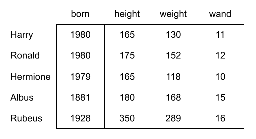

Figure 1: Fictitious Characters Data

## 2.1 Creating Vectors

Create vectors for the columns in the data table displayed above, according to the following data types. If there are missing values, encode them as `NA`.

- `name`: character vector (name of individual)
- `born`: integer vector (years)
- `height`: real (i.e. double) vector (cm)
- `weight`: real (i.e. double) vector (lbs)
- `wand`: integer vector (length of wand, in inches)

# 3 Matrix FIVE

## 3.1 Creating a Matrix

Use the vectors created in the preceding part to create a matrix `FIVE`. This matrix should have dimensions: 5 rows, and 4 columns (born, height, weight, and wand). Also, give names to both the rows and columns of `FIVE` according to figure 1; and display this matrix.

## 3.2 Subscripting (aka Indexing, Slicing) a Matrix

Refer to the matrix `FIVE`.

[output not shown]

3. Using `FIVE`, write a command that gives you the name of the oldest individual. *Hint*: `which.min()` is your friend.
4. Using `FIVE`, write a command that gives you the number of individuals that have a wand length greater than or equal to 13. *Hint*: the function `sum()` is your friend.
5. Using `FIVE`, write a command that arranges its content by `weight` in decreasing order. *Hint*: the function `order()` is your friend.
6. Add a new row to `FIVE` with the data of Bellatrix given below. *Hint*: the `rbind()` function is your friend. Display the updated `FIVE` matrix. To clarify: `FIVE` should have 6 rows (Bellatrix’s data in row 6), and it should also include Bellatrix’s name in the row names.
- name: Bellatrix
- born: 1951
- height: 157
- weight: NA
- wand (length): 13
7. Add a column `ratio` to `FIVE`. The values of `ratio` should be the ratio of height over weight (i.e. height divided by weight). *Hint*: the `cbind()` function is your friend. Display the updated `FIVE` matrix. To clarify: `FIVE` should have 6 rows and 5 columns.

# 4 List of Harry Potter Characters

Create a list `five` containing the vectors created in problem 2. This list should have five elements (one vector per element). Make sure each element of the list has the corresponding name so that you can refer to them by invoking either `five$name` or `five[["name"]]`. Display your `five` list.

## Rubric

- 😞 **None (0 pts)**: No submission; or terribly wrong; or incorrect files.
- 😟 **Deficient (1 pt)**: Displays minimal effort. Fairly incomplete. Code is badly written and/or has various major issues.
- 🙁 **Needs improvement (2 pts)**: Displays some effort. Doesn’t complete all components. Code is poorly written and/or has various minor issues, possibly including a major issue or mistake.
- 😐 **Fair (3 pts)**: Decent effort. Hits all the elements. Possibly a couple of minor mistakes or some non-minor issue. Code written succinctly, but it could be better documented, and/or formatted.
- 🙂 **Good (4 pts)**: Solid effort. Hits all the elements. Possibly a minor mistake. Fairly easy to follow (both the code and the output).
- 😀 **Excellent (5 pts)**: Finished all components of the assignment correctly (without any issues, bugs, mistakes). Code written succinctly, well documented, and easy to follow (both the code and the output).